# Explore and Summarize Data/Red Wine Analysis

========================================================

# Overview

This anaylysis report is described what are important variables for wine quality. wineQualityReds.csv is consist of 13 columns and 1599 row, and each row means one wine

## Understand the meaning of each columns

We need to understand what the meaning of each column.

1. fixed acidity: most acids involved with wine or fixed or nonvolatile (do not evaporate readily)
2. volatile acidity: the amount of acetic acid in wine, which at too high of levels can lead to an unpleasant, vinegar taste
3. citric acid: found in small quantities, citric acid can add ‘freshness’ and flavor to wines
4. residual sugar: the amount of sugar remaining after fermentation stops, it’s rare to find wines with less than 1 gram/liter and wines with greater than 45 grams/liter are considered sweet
5. chlorides: the amount of salt in the wine
6. free sulfur dioxide: the free form of SO2 exists in equilibrium between molecular SO2 (as a dissolved gas) and bisulfite ion; it prevents microbial growth and the oxidation of wine
7. total sulfur dioxide: amount of free and bound forms of S02; in low concentrations, SO2 is mostly undetectable in wine, but at free SO2 concentrations over 50 ppm, SO2 becomes evident in the nose and taste of wine
8. density: the density of water is close to that of water depending on the percent alcohol and sugar content
9. pH: describes how acidic or basic a wine is on a scale from 0 (very acidic) to 14 (very basic); most wines are between 3-4 on the pH scale
10. sulphates: a wine additive which can contribute to sulfur dioxide gas (S02) levels, wich acts as an antimicrobial and antioxidant
11. alcohol: the percent alcohol content of the wine
12. quality (score between 0 and 10)

# Cleaning data

## quality column issue

Quality column can be cleaned as min is 3, and max is 8. For easy understanding, we can adjust it, min is 1 and max is 6.

```
##    Min. 1st Qu.  Median    Mean 3rd Qu.    Max.
##   3.000   5.000   6.000   5.636   6.000   8.000
```

```
##    Min. 1st Qu.  Median    Mean 3rd Qu.    Max.
##   1.000   3.000   4.000   3.636   4.000   6.000
```

## Quality as a factor

Change quality to factor from int, is better for analysis below

```
##   1   2   3   4   5   6
##  10  53 681 638 199  18
```

# Univariate Plots Section

## Basic distribution of wine/quality

Here is a basic distribution of wine as per its quality, before we do further analysis for multiple variables

- Most of wine quality is 3 or 4
- Small number of win quality is 5 or 6
  - Quality 1 : 10
  - Quality 2 : 53
  - Quality 3 : 681
  - Quality 4 : 638
  - Quality 5 : 199
  - Quality 6 : 18

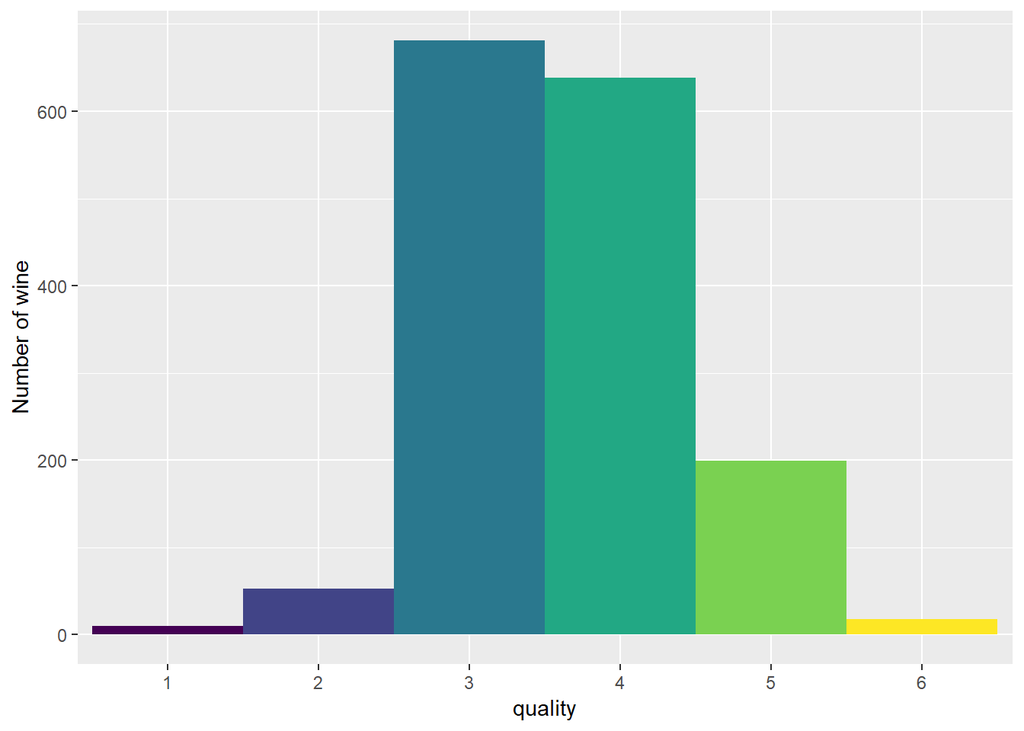